# Sex Differences in Functional Connectivity

Audrey Luo

```r
# load S-A axis
schaefer200x17_SAaxis <- read.csv("/cbica/projects/network_replication/SAaxis/schaefer200x17_SAaxis.csv")
schaefer200x17_SAaxis <- schaefer200x17_SAaxis %>% rename(region=label)

# load parcel labels
schaefer200x17.labels <- read.csv("/cbica/projects/network_replication/atlases/parcellations/schaefer200x17_regionlist_final.csv")
schaefer200x17.labels <- schaefer200x17.labels$label

# load network-pair labels
schaefer200x17.networkpair.labels <- read.csv("/cbica/projects/network_replication/atlases/parcellations/schaefer200x17_netpair_labels_noduplicates.csv")
schaefer200x17.networkpair.labels <- schaefer200x17.networkpair.labels[,1]

# load permuted schaefer200
perm.id.full_schaefer200x17 <- readRDS("/cbica/projects/network_replication/software/rotate_parcellation/schaefer200x17.coords_sphericalrotations_N10k_seed10.rds")
```

# 1. Sex differences in between- and within-network connectivity

Thus, we hypothesized that males would show greater between-network connectivity, whereas females would show greater within-network connectivity.

```r
sex.main.PNC.BNC <- read.csv(sprintf("%1$s/%2$s/GAM/%3$s/%2$s_GAM_sex_maineffects_schaefer200x17.csv", output_root, "PNC", "BNC"))
sex.main.PNC.BNC$region <- paste0("17", sex.main.PNC.BNC$region)
sex.main.PNC.BNC <- sig.effects(sex.main.PNC.BNC, "BNC", "sex", "PNC")
```

```
## [1] "PNC: 149 regions (74.5 percent) show a significant association between BNC and sex"
```

```r
sex.main.HCPD.BNC <- read.csv(sprintf("%1$s/%2$s/GAM/%3$s/%2$s_GAM_sex_maineffects_schaefer200x17.csv", output_root, "HCPD", "BNC"))
sex.main.HCPD.BNC <- sig.effects(sex.main.HCPD.BNC, "BNC", "sex", "HCPD")
```

```
## [1] "HCPD: 73 regions (36.5 percent) show a significant association between BNC and sex"
```

```r
sex.main.HCPD.BNC$region <- paste0("17", sex.main.HCPD.BNC$region)

sex.main.NKI.BNC <- read.csv(sprintf("%1$s/%2$s/GAM/%3$s/%2$s_GAM_sex_maineffects_schaefer200x17.csv", output_root, "NKI", "BNC"))
sex.main.NKI.BNC <- sig.effects(sex.main.NKI.BNC, "BNC", "sex", "NKI")
```

```
## [1] "NKI: 28 regions (14 percent) show a significant association between BNC and sex"
```

```r
sex.main.NKI.BNC$region <- paste0("17", sex.main.NKI.BNC$region)

sex.main.HBN.BNC <- read.csv(sprintf("%1$s/%2$s/GAM/%3$s/%2$s_GAM_sex_maineffects_schaefer200x17.csv", output_root, "HBN", "BNC"))
sex.main.HBN.BNC <- sig.effects(sex.main.HBN.BNC, "BNC", "sex", "HBN")
```

```
## [1] "HBN: 78 regions (39 percent) show a significant association between BNC and sex"
```

```r
sex.main.HBN.BNC$region <- paste0("17", sex.main.HBN.BNC$region)

sex.main.all_datasets.BNC <- read.csv(sprintf("%1$s/%2$s/GAM/%3$s/%2$s_GAM_sex_maineffects_schaefer200x17.csv", output_root, "all_datasets", "BNC"))
sex.main.all_datasets.BNC <- sig.effects(sex.main.all_datasets.BNC, "BNC", "sex", "all_datasets")
```

```
## [1] "all_datasets: 176 regions (88 percent) show a significant association between BNC and sex"
```

```r
sex.main.all_datasets.BNC$region <- paste0("17", sex.main.all_datasets.BNC$region)

#range(sex.main.PNC.BNC$GAM.cov.tvalue)
#range(sex.main.HCPD.BNC$GAM.cov.tvalue)
#range(sex.main.HBN.BNC$GAM.cov.tvalue)
#range(sex.main.NKI.BNC$GAM.cov.tvalue)
#range(sex.main.all_datasets.BNC$GAM.cov.tvalue)

sex.main.PNC.WNC <- read.csv(sprintf("%1$s/%2$s/GAM/%3$s/%2$s_GAM_sex_maineffects_schaefer200x17.csv", output_root, "PNC", "WNC"))
sex.main.PNC.WNC$region <- paste0("17", sex.main.PNC.WNC$region)
sex.main.PNC.WNC <- sig.effects(sex.main.PNC.WNC, "WNC", "sex", "PNC")
```

```
## [1] "PNC: 73 regions (36.5 percent) show a significant association between WNC and sex"
```

```r
sex.main.HCPD.WNC <- read.csv(sprintf("%1$s/%2$s/GAM/%3$s/%2$s_GAM_sex_maineffects_schaefer200x17.csv", output_root, "HCPD", "WNC"))
sex.main.HCPD.WNC <- sig.effects(sex.main.HCPD.WNC, "WNC", "sex", "HCPD")
```

```
## [1] "HCPD: 45 regions (22.5 percent) show a significant association between WNC and sex"
```

```r
sex.main.HCPD.WNC$region <- paste0("17", sex.main.HCPD.WNC$region)

sex.main.NKI.WNC <- read.csv(sprintf("%1$s/%2$s/GAM/%3$s/%2$s_GAM_sex_maineffects_schaefer200x17.csv", output_root, "NKI", "WNC"))
sex.main.NKI.WNC <- sig.effects(sex.main.NKI.WNC, "WNC", "sex", "NKI")
```

```
## [1] "NKI: 12 regions (6 percent) show a significant association between WNC and sex"
```

```r
sex.main.NKI.WNC$region <- paste0("17", sex.main.NKI.WNC$region)

sex.main.HBN.WNC <- read.csv(sprintf("%1$s/%2$s/GAM/%3$s/%2$s_GAM_sex_maineffects_schaefer200x17.csv", output_root, "HBN", "WNC"))
sex.main.HBN.WNC <- sig.effects(sex.main.HBN.WNC, "WNC", "sex", "HBN")
```

```
## [1] "HBN: 35 regions (17.5 percent) show a significant association between WNC and sex"
```

```r
sex.main.HBN.WNC$region <- paste0("17", sex.main.HBN.WNC$region)

sex.main.all_datasets.WNC <- read.csv(sprintf("%1$s/%2$s/GAM/%3$s/%2$s_GAM_sex_maineffects_schaefer200x17.csv", output_root, "all_datasets", "WNC"))
sex.main.all_datasets.WNC <- sig.effects(sex.main.all_datasets.WNC, "WNC", "sex", "all_datasets")
```

```
## [1] "all_datasets: 102 regions (51 percent) show a significant association between WNC and sex"
```

```r
sex.main.all_datasets.WNC$region <- paste0("17", sex.main.all_datasets.WNC$region)

#range(sex.main.PNC.WNC$GAM.cov.tvalue)
#range(sex.main.HCPD.WNC$GAM.cov.tvalue)
#range(sex.main.HBN.WNC$GAM.cov.tvalue)
#range(sex.main.NKI.WNC$GAM.cov.tvalue)
#range(sex.main.all_datasets.WNC$GAM.cov.tvalue)
```

```r
sex.main.PNC.BNC_lh <- plot_cortex(sex.main.PNC.BNC, hemi = "left", measure = "cov_sig_effect", ylim1 = -2, ylim2 = 10, atlas = "schaefer17_200")
sex.main.PNC.BNC_rh <- plot_cortex(sex.main.PNC.BNC, hemi = "right", measure = "cov_sig_effect", ylim1 = -2, ylim2 = 10, atlas = "schaefer17_200")

sex.main.HCPD.BNC_lh <- plot_cortex(sex.main.HCPD.BNC, hemi = "left", measure = "cov_sig_effect", ylim1 = -2, ylim2 = 10, atlas = "schaefer17_200")
sex.main.HCPD.BNC_rh <- plot_cortex(sex.main.HCPD.BNC, hemi = "right", measure = "cov_sig_effect", ylim1 = -2, ylim2 = 10, atlas = "schaefer17_200")

sex.main.NKI.BNC_lh <- plot_cortex(sex.main.NKI.BNC, hemi = "left", measure = "cov_sig_effect", ylim1 = -2, ylim2 = 10, atlas = "schaefer17_200")
sex.main.NKI.BNC_rh <- plot_cortex(sex.main.NKI.BNC, hemi = "right", measure = "cov_sig_effect", ylim1 = -2, ylim2 = 10, atlas = "schaefer17_200")

sex.main.HBN.BNC_lh <- plot_cortex(sex.main.HBN.BNC, hemi = "left", measure = "cov_sig_effect", ylim1 = -2, ylim2 = 10, atlas = "schaefer17_200")
sex.main.HBN.BNC_rh <- plot_cortex(sex.main.HBN.BNC, hemi = "right", measure = "cov_sig_effect", ylim1 = -2, ylim2 = 10, atlas = "schaefer17_200")

sex.main.all_datasets.BNC_lh <- plot_cortex(sex.main.all_datasets.BNC, hemi = "left", measure = "cov_sig_effect", ylim1 = -2, ylim2 = 10, atlas = "schaefer17_200", horizontal_layout = TRUE)
sex.main.all_datasets.BNC_rh <- plot_cortex(sex.main.all_datasets.BNC, hemi = "right", measure = "cov_sig_effect", ylim1 = -2, ylim2 = 10, atlas = "schaefer17_200", horizontal_layout = TRUE)


#####
# legend
ylim1 = -2
ylim2 = 10
p <- ggplot() +
    geom_brain(data = sex.main.HBN.BNC, atlas = schaefer17_200,
               mapping=aes(fill=GAM.cov.tvalue),
               show.legend=TRUE) +
     scale_fill_gradientn(colours = c("#EE4684", "white", "#009EA4"),
                          values = scales::rescale(c(ylim1, 0, ylim2)), limits = c(ylim1, ylim2), oob = squish, na.value = "white") +
    theme_void()  +
    theme(legend.title = element_blank(),
          legend.text = element_text(size = 24),
        legend.position = "bottom",
        legend.box = "horizontal",
        legend.key.height = unit(1, 'cm'),
        legend.key.width = unit(2, 'cm'),
        plot.margin = unit(c(0, 1, 0, -0.5), "cm"))

legend <- get_legend(p)

# arrange plots
# PNC
BNC_PNC <- annotate_figure(
  plot_grid(sex.main.PNC.BNC_lh, sex.main.PNC.BNC_rh, ncol = 2),
  top = text_grob("PNC", size = 24)
)

# HCP-D
BNC_HCPD <- annotate_figure(
  plot_grid(sex.main.HCPD.BNC_lh, sex.main.HCPD.BNC_rh, ncol = 2),
  top = text_grob("HCP-D", size = 24)
)

# NKI
BNC_NKI <- annotate_figure(
  plot_grid(sex.main.NKI.BNC_lh, sex.main.NKI.BNC_rh, ncol = 2),
  top = text_grob("NKI", size = 24)
)

# HBN
BNC_HBN <- annotate_figure(
  plot_grid(sex.main.HBN.BNC_lh, sex.main.HBN.BNC_rh, ncol = 2),
  top = text_grob("HBN", size = 24)
)

# pooled dataset / all datasets
BNC_all <- annotate_figure(
  plot_grid(sex.main.all_datasets.BNC_lh, sex.main.all_datasets.BNC_rh, ncol = 2),
  top = text_grob("Pooled Dataset", size = 24)
)

# blank plot for formatting
blank_space <- ggplot() + theme_void()

BNC_plots <- annotate_figure(
  plot_grid(
    blank_space,
    plot_grid(BNC_PNC, BNC_HCPD, BNC_NKI, BNC_HBN, ncol = 2),
    BNC_all,
    legend,
    blank_space,
    nrow = 5,
    rel_heights = c(0.05, 1, 0.29, 0.2, 0.05)
  ),
  top = text_grob("Between Network Connectivity", size = 24, face = "bold"),
  bottom = text_grob("Sex Effect (t-value)", size = 24, y = 2)
)
```

```r
# overlap plots
df_list_BNC <- list(
  PNC  = sex.main.PNC.BNC[, c("region", "Anova.cov.pvalue.fdr")] |> rename(p_PNC = Anova.cov.pvalue.fdr),
  HCPD = sex.main.HCPD.BNC[, c("region", "Anova.cov.pvalue.fdr")] |> rename(p_HCPD = Anova.cov.pvalue.fdr),
  NKI  = sex.main.NKI.BNC[,  c("region", "Anova.cov.pvalue.fdr")] |> rename(p_NKI = Anova.cov.pvalue.fdr),
  HBN  = sex.main.HBN.BNC[,  c("region", "Anova.cov.pvalue.fdr")] |> rename(p_HBN = Anova.cov.pvalue.fdr)
)

sex.main.overlap.BNC <- Reduce(function(x, y) full_join(x, y, by = "region"), df_list_BNC)
sex.main.overlap.BNC$signif_count <- rowSums(sex.main.overlap.BNC[, -1] < 0.05, na.rm = TRUE)
sex.main.overlap.BNC$signif_count_factor <- factor(
  sex.main.overlap.BNC$signif_count,
  levels = 0:4,
  labels = c("0", "1", "2", "3", "4")
)
sex.main.overlap.BNC <- sex.main.overlap.BNC %>% mutate(signif_greater_than_one = ifelse(signif_count > 1, "1", "0"))

count_colors <- c(
  "0" = "white",
  "1" = "white",
  "2" = "#FAF7C2",
  "3" = "#FFDE58",
  "4" = "#FFA256"
)

BNC_overlap.lh <- plot_cortex_overlap(sex.main.overlap.BNC, hemi = "left", atlas = "schaefer17_200", horizontal_layout = T)
BNC_overlap.rh <- plot_cortex_overlap(sex.main.overlap.BNC, hemi = "right", atlas = "schaefer17_200", horizontal_layout = T)

BNC_overlap <- annotate_figure(
  plot_grid(BNC_overlap.lh, BNC_overlap.rh, ncol = 2),
  top = text_grob("Overlap of Significant Effects Across Datasets", size = 24)
)
# legend for overlap
count_colors_legend <- c(
  "0–1" = "white",
  "2"   = "#FAF7C2",
  "3"   = "#FFDE58",
  "4"   = "#FFA256"
)

legend_df <- data.frame(
  overlap = factor(names(count_colors_legend),
                   levels = names(count_colors_legend))
)

legend_plot <- ggplot(data.frame(overlap = factor(names(count_colors_legend),
                                                  levels = names(count_colors_legend))),
                      aes(x = overlap, fill = overlap)) +
  geom_bar() +
  scale_fill_manual(
    values = count_colors_legend,
    guide = guide_legend(
      direction = "horizontal",
      label.position = "bottom",
      override.aes = list(
        colour = "black",   # outline boxes
        size = 1
      )
    )
  ) +
  theme_void() +
  theme(
    legend.title = element_blank(),
    legend.text  = element_text(size = 18),
    legend.key.size = unit(1.3, "cm"),
    legend.position = "bottom"
  )

# Extract the horizontal legend
overlap_legend <- get_legend(legend_plot)

overlap_BNC_plots <- annotate_figure(plot_grid(BNC_overlap, overlap_legend, nrow = 2, rel_heights = c(1, 0.2)),
                                     bottom = text_grob("Number of Datasets", size = 24, y = 0.1))


BNC_plots_final <- plot_grid(BNC_plots, overlap_BNC_plots, blank_space, nrow = 3, rel_heights = c(1, 0.3, 0.01), rel_widths = c(1, 0.9, 1))
```

```r
# WNC
sex.main.PNC.WNC_lh <- plot_cortex(sex.main.PNC.WNC, hemi = "left", measure = "cov_sig_effect", ylim1 = -11, ylim2 = 8, atlas = "schaefer17_200")
sex.main.PNC.WNC_rh <- plot_cortex(sex.main.PNC.WNC, hemi = "right", measure = "cov_sig_effect", ylim1 = -11, ylim2 = 8, atlas = "schaefer17_200")

sex.main.HCPD.WNC_lh <- plot_cortex(sex.main.HCPD.WNC, hemi = "left", measure = "cov_sig_effect", ylim1 = -11, ylim2 = 8, atlas = "schaefer17_200")
sex.main.HCPD.WNC_rh <- plot_cortex(sex.main.HCPD.WNC, hemi = "right", measure = "cov_sig_effect", ylim1 = -11, ylim2 = 8, atlas = "schaefer17_200")

sex.main.NKI.WNC_lh <- plot_cortex(sex.main.NKI.WNC, hemi = "left", measure = "cov_sig_effect", ylim1 = -11, ylim2 = 8, atlas = "schaefer17_200")
sex.main.NKI.WNC_rh <- plot_cortex(sex.main.NKI.WNC, hemi = "right", measure = "cov_sig_effect", ylim1 = -11, ylim2 = 8, atlas = "schaefer17_200")

sex.main.HBN.WNC_lh <- plot_cortex(sex.main.HBN.WNC, hemi = "left", measure = "cov_sig_effect", ylim1 = -11, ylim2 = 8, atlas = "schaefer17_200")
sex.main.HBN.WNC_rh <- plot_cortex(sex.main.HBN.WNC, hemi = "right", measure = "cov_sig_effect", ylim1 = -11, ylim2 = 8, atlas = "schaefer17_200")

sex.main.all_datasets.WNC_lh <- plot_cortex(sex.main.all_datasets.WNC, hemi = "left", measure = "cov_sig_effect", ylim1 = -2, ylim2 = 10, atlas = "schaefer17_200", horizontal_layout = TRUE)
sex.main.all_datasets.WNC_rh <- plot_cortex(sex.main.all_datasets.WNC, hemi = "right", measure = "cov_sig_effect", ylim1 = -2, ylim2 = 10, atlas = "schaefer17_200", horizontal_layout = TRUE)

# legend
ylim1 = -11
ylim2 = 8
p <- ggplot() +
    geom_brain(data = sex.main.HBN.WNC, atlas = schaefer17_200,
               mapping=aes(fill=GAM.cov.tvalue),
               show.legend=TRUE) +
     scale_fill_gradientn(colours = c("#EE4684", "white", "#009EA4"),
                          values = scales::rescale(c(ylim1, 0, ylim2)), limits = c(ylim1, ylim2), oob = squish, na.value = "white") +
    theme_void()  +
    theme(legend.title = element_blank(),
          legend.text = element_text(size = 24),
        legend.position = "bottom",
        legend.box = "horizontal",
        legend.key.height = unit(1, 'cm'),
        legend.key.width = unit(2, 'cm'),
        plot.margin = unit(c(0, 1, 0, -0.5), "cm"))

legend <- get_legend(p)

# PNC
WNC_PNC <- annotate_figure(
  plot_grid(sex.main.PNC.WNC_lh, sex.main.PNC.WNC_rh, ncol = 2),
  top = text_grob("PNC", size = 24)
)

# HCP-D
WNC_HCPD <- annotate_figure(
  plot_grid(sex.main.HCPD.WNC_lh, sex.main.HCPD.WNC_rh, ncol = 2),
  top = text_grob("HCP-D", size = 24)
)

# NKI
WNC_NKI <- annotate_figure(
  plot_grid(sex.main.NKI.WNC_lh, sex.main.NKI.WNC_rh, ncol = 2),
  top = text_grob("NKI", size = 24)
)

# HBN
WNC_HBN <- annotate_figure(
  plot_grid(sex.main.HBN.WNC_lh, sex.main.HBN.WNC_rh, ncol = 2),
  top = text_grob("HBN", size = 24)
)

# All Datasets
WNC_all <- annotate_figure(
  plot_grid(sex.main.all_datasets.WNC_lh, sex.main.all_datasets.WNC_rh, ncol = 2),
  top = text_grob("Pooled Dataset", size = 24)
)


WNC_plots <- annotate_figure(
  plot_grid(
    blank_space,
    plot_grid(WNC_PNC, WNC_HCPD, WNC_NKI, WNC_HBN, ncol = 2),
    WNC_all,
    legend,
    blank_space,
    nrow = 5,
    rel_heights = c(0.05, 1, 0.29, 0.2, 0.05)
  ),
  top = text_grob("Within Network Connectivity", size = 24, face = "bold"),
  bottom = text_grob("Sex Effect (t-value)", size = 24, y = 2)
)
```

```r
# overlap plots
df_list_WNC <- list(
  PNC  = sex.main.PNC.WNC[, c("region", "Anova.cov.pvalue.fdr")] |> rename(p_PNC = Anova.cov.pvalue.fdr),
  HCPD = sex.main.HCPD.WNC[, c("region", "Anova.cov.pvalue.fdr")] |> rename(p_HCPD = Anova.cov.pvalue.fdr),
  NKI  = sex.main.NKI.WNC[,  c("region", "Anova.cov.pvalue.fdr")] |> rename(p_NKI = Anova.cov.pvalue.fdr),
  HBN  = sex.main.HBN.WNC[,  c("region", "Anova.cov.pvalue.fdr")] |> rename(p_HBN = Anova.cov.pvalue.fdr)
)

sex.main.overlap.WNC <- Reduce(function(x, y) full_join(x, y, by = "region"), df_list_WNC)
sex.main.overlap.WNC$signif_count <- rowSums(sex.main.overlap.WNC[, -1] < 0.05, na.rm = TRUE)
sex.main.overlap.WNC$signif_count_factor <- factor(
  sex.main.overlap.WNC$signif_count,
  levels = 0:4,
  labels = c("0", "1", "2", "3", "4")
)
sex.main.overlap.WNC <- sex.main.overlap.WNC %>% mutate(signif_greater_than_one = ifelse(signif_count > 1, "1", "0"))
WNC_overlap.lh <- plot_cortex_overlap(sex.main.overlap.WNC, hemi = "left", atlas = "schaefer17_200", horizontal_layout = T)
WNC_overlap.rh <- plot_cortex_overlap(sex.main.overlap.WNC, hemi = "right", atlas = "schaefer17_200", horizontal_layout = T)

WNC_overlap <- annotate_figure(
  plot_grid(WNC_overlap.lh, WNC_overlap.rh, ncol = 2),
  top = text_grob("Overlap of Significant Effects Across Datasets", size = 24)
)

overlap_WNC_plots <- annotate_figure(plot_grid(WNC_overlap, overlap_legend, nrow = 2, rel_heights = c(1, 0.2)),
                                     bottom = text_grob("Number of Datasets", size = 24, y = 0.1))


WNC_plots_final <- plot_grid(WNC_plots, overlap_WNC_plots, blank_space, nrow = 3, rel_heights = c(1, 0.3, 0.01), rel_widths = c(1, 0.9, 1))
```

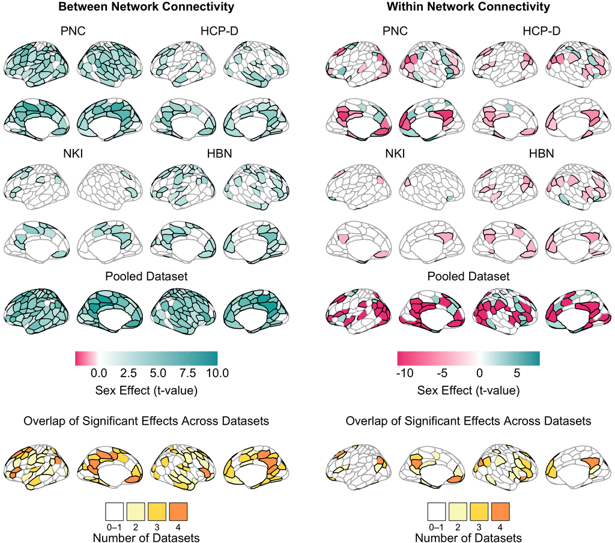

```r
# final plot
plot_grid(BNC_plots_final, blank_space, WNC_plots_final, ncol = 3, rel_widths = c(1, 0.1, 1))
```

## maybe look at network segregation and integration

## 1.1: supplementary figure - GBC?

## 1.2: supplement figure - null correlations with S-A axis?

## 1.3: age-by-sex

# 2. parcels showing sex differences are involved in X cognitive functions via neurosynth

Which Neurosynth terms show significant functional activation (z > 1.64) within the parcels where females have higher WNC? What about where males have higher BNC?

```r
# code adapted from Val Sydnor's https://github.com/PennLINC/thalamocortical_development/blob/main/results/developmental_effects/thalamocortical_connectivity_development.Rmd
#Neurosynth z-score maps generated by nimare. Nimare uses multilevel kernel density analysis- Chi-square analysis + FDR-correction to use the same procedure as Neurosynth
neurosynth.terms <- read.csv("/cbica/projects/network_replication/covariate_analyses/sex_diff/input/neurosynth_annotations/schaefer200/schaefer200x17_neurosynth_125terms.csv") %>% select(-regionID) %>% rename(region = label)
neurosynth.termlist <- names(neurosynth.terms)[-1] #list of terms
```

We examined the 10 most positively correlated Neurosynth terms with the BNC sex difference map, focusing on positive correlations because they indicate cognitive domains whose spatial patterns overlap with parcels showing greater BNC in males relative to females. In contrast, we examined the ten most negatively correlated Neurosynth terms with the WNC sex difference map, focusing on negatively correlations because they indicate cognitive domains whose spatial patterns overlap with parcels showing greater WNC in females relative to males.

```r
# identify overlapping significant effects across datasets (2 or more datasets), and get avg t-value for each of those parcels
BNC_sexeffect_overlap <- identify_sexeffect_overlap("BNC") %>% mutate(significant_status = ifelse(signif_2plus == 1, "Sig", "Nonsig"))
WNC_sexeffect_overlap <- identify_sexeffect_overlap("WNC") %>% mutate(significant_status = ifelse(signif_2plus == 1, "Sig", "Nonsig"))

# fdr correction of neurosynth terms correlations with BNC and WNC sex effect maps
BNC_neurosynth <- read.csv("/cbica/projects/network_replication/covariate_analyses/sex_diff/output/all_datasets/spin_test/neurosynth/BNC_neurosynth_spin_test_results_overlap.csv")
BNC_neurosynth$pvalue.fdr <- p.adjust(BNC_neurosynth$p_spin, method = c("fdr"))
BNC_neurosynth_fdr <- BNC_neurosynth %>% filter(pvalue.fdr < 0.05)
BNC_neurosynth_top10 <- rbind(slice_max(BNC_neurosynth_fdr, order_by = term.correlation, n = 10)) # 10 most positively correlated neurosynth terms with the sex diff map. Looking at positive correlations because they reflect cognitive terms that spatially align with regions showing higher BNC in males (male > female).
BNC_neurosynth_top10$term <- tools::toTitleCase(gsub("_", " ", BNC_neurosynth_top10$term))

WNC_neurosynth <- read.csv("/cbica/projects/network_replication/covariate_analyses/sex_diff/output/all_datasets/spin_test/neurosynth/WNC_neurosynth_spin_test_results_overlap.csv")
WNC_neurosynth$pvalue.fdr <- p.adjust(WNC_neurosynth$p_spin, method = c("fdr"))
WNC_neurosynth_fdr <- WNC_neurosynth %>% filter(pvalue.fdr < 0.05)
WNC_neurosynth_top10 <- rbind(slice_min(WNC_neurosynth_fdr, order_by = term.correlation, n = 10)) # 10 most negatively correlated neurosynth terms with the sex diff map. Looking at NEGATIVE correlations because they reflect cognitive terms that spatially align with regions showing higher WNC in females (female > male).
WNC_neurosynth_top10$term <- tools::toTitleCase(gsub("_", " ", WNC_neurosynth_top10$term))
WNC_neurosynth_top10$term <- gsub("Autobiographical Memory", "Autobio. Memory", WNC_neurosynth_top10$term)
```

```r
# plot avg t-value
BNC_overlap_tvalue_plot_lh <- plot_cortex(BNC_sexeffect_overlap, hemi = "left", measure = "mean_t_sig2", ylim1 = -0.5, ylim2 = 5.5, atlas = "schaefer17_200")
BNC_overlap_tvalue_plot_rh <- plot_cortex(BNC_sexeffect_overlap, hemi = "right", measure = "mean_t_sig2", ylim1 = -0.5, ylim2 = 5.5, atlas = "schaefer17_200")

WNC_overlap_tvalue_plot_lh <- plot_cortex(WNC_sexeffect_overlap, hemi = "left", measure = "mean_t_sig2", ylim1 = -6, ylim2 = 5, atlas = "schaefer17_200")
WNC_overlap_tvalue_plot_rh <- plot_cortex(WNC_sexeffect_overlap, hemi = "right", measure = "mean_t_sig2", ylim1 = -6, ylim2 = 5, atlas = "schaefer17_200")

# legend for BNC overlap
ylim1 = -0.5
ylim2 = 5.5
p_BNC <- ggplot() +
    geom_brain(data = BNC_sexeffect_overlap, atlas = schaefer17_200,
               mapping=aes(fill=mean_t_sig2),
               show.legend=TRUE) +
     scale_fill_gradientn(colours = c("#EE4684", "white", "#009EA4"),
                          values = scales::rescale(c(ylim1, 0, ylim2)), limits = c(ylim1, ylim2), oob = squish, na.value = "white") +
    theme_void()  +
    theme(legend.title = element_blank(),
          legend.text = element_text(size = 24),
        legend.position = "bottom",
        legend.box = "horizontal",
        legend.key.height = unit(1, 'cm'),
        legend.key.width = unit(2, 'cm'),
        plot.margin = unit(c(0, 1, 0, -0.5), "cm"))

legend_BNC_overlap <- get_legend(p_BNC)

# legend for WNC overlap
ylim1 = -6
ylim2 = 5
p_WNC <- ggplot() +
    geom_brain(data = WNC_sexeffect_overlap, atlas = schaefer17_200,
               mapping=aes(fill=mean_t_sig2),
               show.legend=TRUE) +
     scale_fill_gradientn(colours = c("#EE4684", "white", "#009EA4"),
                          values = scales::rescale(c(ylim1, 0, ylim2)), limits = c(ylim1, ylim2), oob = squish, na.value = "white") +
    theme_void()  +
    theme(legend.title = element_blank(),
          legend.text = element_text(size = 24),
        legend.position = "bottom",
        legend.box = "horizontal",
        legend.key.height = unit(1, 'cm'),
        legend.key.width = unit(2, 'cm'),
        plot.margin = unit(c(0, 1, 0, -0.5), "cm"))

legend_WNC_overlap <- get_legend(p_WNC)


# arrange plots
BNC_overlap_tvalue_plot <- annotate_figure(
  plot_grid(
    blank_space,
    annotate_figure(plot_grid(BNC_overlap_tvalue_plot_lh, BNC_overlap_tvalue_plot_rh, ncol = 2),
                    top = text_grob("Overlap of Significant Effects Across Datasets \n (Average T-value)", size = 20)),
    blank_space,
    legend_BNC_overlap,
    blank_space,
    nrow = 5,
    rel_heights = c(0.05, 1, 0.1, 0.1, 0.1)
  ),
  top = text_grob("Between Network Connectivity", size = 24, face = "bold"),
  bottom = text_grob("Sex Effect (t-value)", size = 24, y = 1)
)



WNC_overlap_tvalue_plot <- annotate_figure(
  plot_grid(
    blank_space,
    annotate_figure(plot_grid(WNC_overlap_tvalue_plot_lh, WNC_overlap_tvalue_plot_rh, ncol = 2),
                    top = text_grob("Overlap of Significant Effects Across Datasets \n (Average T-value)", size = 20)),
    blank_space,
    legend_WNC_overlap,
    blank_space,
    nrow = 5,
    rel_heights = c(0.05, 1, 0.1, 0.1, 0.1)
  ),
  top = text_grob("Within Network Connectivity", size = 24, face = "bold"),
  bottom = text_grob("Sex Effect (t-value)", size = 24, y = 1)
)
```

```r
# plot neurosynth terms
BNC_neurosynth_plot <- ggplot(BNC_neurosynth_top10,
       aes(x = term.correlation,
           y = reorder(term, abs(term.correlation)))) +
  geom_segment(aes(x = 0, xend = term.correlation,
                   yend = reorder(term, abs(term.correlation))),
               color = "gray80", linewidth = 0.9) +
  geom_point(aes(color = term.correlation), size = 12) +
  scale_color_gradient(low = "#A8E4E2", high = "#008984") +
  scale_x_continuous(limits = c(0, 0.6), breaks = seq(0, 0.6, by = 0.2),
                     expand = c(0, 0)) +
  scale_y_discrete(position = "left") +
  labs(
    x = "Spatial Correlation",
    y = "Neurosynth Term"
  ) +
  theme_classic() +
  coord_cartesian(clip = "off") +
  theme(
    panel.grid.major.y = element_blank(),
    panel.grid.minor = element_blank(),
    legend.position = "none",
    axis.title.y = element_text(size = 20, color = "black"),
    axis.title.x = element_text(size = 20, color = "black"),
    axis.text.y = element_text(size = 20, color = "black"),
    axis.text.x = element_text(size = 20, color = "black"),
    plot.margin = unit(c(0, 1, 0, 0), "cm")
  )

WNC_neurosynth_plot <- ggplot(WNC_neurosynth_top10,
       aes(x = term.correlation,
           y = reorder(term, abs(term.correlation)))) +
  geom_segment(aes(x = 0, xend = term.correlation,
                   yend = reorder(term, -abs(term.correlation))),
               color = "gray80", linewidth = 0.9) +
  geom_point(aes(color = term.correlation), size = 12) +
  scale_color_gradient(low = "#E73D7B", high = "#FFBDD5") +
  scale_x_continuous(limits = c(-0.6, 0), breaks = seq(-0.6, 0, by = 0.2),
                     expand = c(0, 0)) +
  scale_y_discrete(position = "right") +
  labs(
    x = "Spatial Correlation") +
  theme_classic() +
  coord_cartesian(clip = "off") +
  theme(
    panel.grid.major.y = element_blank(),
    panel.grid.minor = element_blank(),
    legend.position = "none",
    axis.title.y = element_blank(),
    axis.title.x = element_text(size = 20, color = "black"),
    axis.text.y = element_text(size = 20, color = "black"),
    axis.text.x = element_text(size = 20, color = "black"),
    plot.margin = unit(c(0, 0, 0, 1), "cm")
  )
```

## option 1: overlap between datasets (average t-value across datasets is spun against neurosynth term maps)

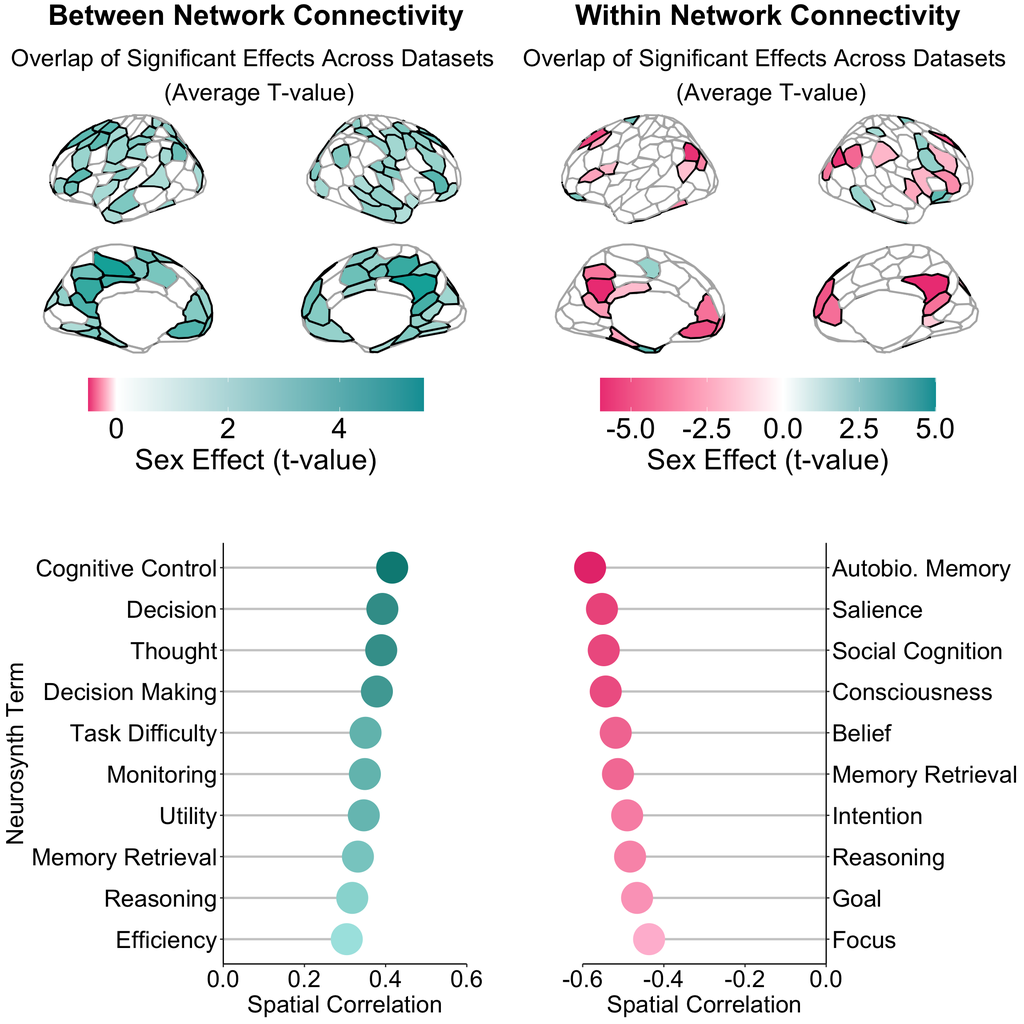

```r
neurosynth_plots_row1 <- plot_grid(BNC_overlap_tvalue_plot, WNC_overlap_tvalue_plot, ncol = 2)
neurosynth_plots_row2 <- plot_grid(blank_space, blank_space, ncol = 2)
neurosynth_plots_row3 <- BNC_neurosynth_plot + blank_space + WNC_neurosynth_plot +
  plot_layout(widths = c(1, 0.2,  1))

plot_grid(neurosynth_plots_row1, neurosynth_plots_row2, neurosynth_plots_row3, nrow = 3, rel_heights = c(1, 0.1, 1))
```

```r
# fdr correction of neurosynth terms correlations with BNC and WNC sex effect maps
BNC_neurosynth_pooled <- read.csv("/cbica/projects/network_replication/covariate_analyses/sex_diff/output/all_datasets/spin_test/neurosynth/BNC_neurosynth_spin_test_results_pooled.csv")
BNC_neurosynth_pooled$pvalue.fdr <- p.adjust(BNC_neurosynth_pooled$p_spin, method = c("fdr"))
BNC_neurosynth_pooled_fdr <- BNC_neurosynth_pooled %>% filter(pvalue.fdr < 0.05)
BNC_neurosynth_pooled_top10 <- rbind(slice_max(BNC_neurosynth_pooled_fdr, order_by = term.correlation, n = 10)) # 10 most positively correlated neurosynth terms with the sex diff map. Looking at positive correlations because they reflect cognitive terms that spatially align with regions showing higher BNC in males (male > female).
BNC_neurosynth_pooled_top10$term <- tools::toTitleCase(gsub("_", " ", BNC_neurosynth_pooled_top10$term))
BNC_neurosynth_pooled_top10$term <- gsub("Autobiographical Memory", "Autobio. Memory", BNC_neurosynth_pooled_top10$term)
BNC_neurosynth_pooled_top10 <- BNC_neurosynth_pooled_top10 %>% filter(term.correlation > 0)

WNC_neurosynth_pooled <- read.csv("/cbica/projects/network_replication/covariate_analyses/sex_diff/output/all_datasets/spin_test/neurosynth/WNC_neurosynth_spin_test_results_pooled.csv")
WNC_neurosynth_pooled$pvalue.fdr <- p.adjust(WNC_neurosynth_pooled$p_spin, method = c("fdr"))
WNC_neurosynth_pooled_fdr <- WNC_neurosynth_pooled %>% filter(pvalue.fdr < 0.05)
WNC_neurosynth_pooled_top10 <- rbind(slice_min(WNC_neurosynth_pooled_fdr, order_by = term.correlation, n = 10)) # 10 most negatively correlated neurosynth terms with the sex diff map. Looking at NEGATIVE correlations because they reflect cognitive terms that spatially align with regions showing higher WNC in females (female > male).
WNC_neurosynth_pooled_top10$term <- tools::toTitleCase(gsub("_", " ", WNC_neurosynth_pooled_top10$term))
WNC_neurosynth_pooled_top10$term <- gsub("Autobiographical Memory", "Autobio. Memory", WNC_neurosynth_pooled_top10$term)
```

```r
# plot avg t-value
BNC_pooled_tvalue_plot_lh <- plot_cortex(sex.main.all_datasets.BNC, hemi = "left", measure = "cov_sig_effect", ylim1 = -0.5, ylim2 = 11, atlas = "schaefer17_200")
BNC_pooled_tvalue_plot_rh <- plot_cortex(sex.main.all_datasets.BNC, hemi = "right", measure = "cov_sig_effect", ylim1 = -0.5, ylim2 = 11, atlas = "schaefer17_200")

WNC_pooled_tvalue_plot_lh <- plot_cortex(sex.main.all_datasets.WNC, hemi = "left", measure = "cov_sig_effect", ylim1 = -13, ylim2 = 10, atlas = "schaefer17_200")
WNC_pooled_tvalue_plot_rh <- plot_cortex(sex.main.all_datasets.WNC, hemi = "right", measure = "cov_sig_effect", ylim1 = -13, ylim2 = 10, atlas = "schaefer17_200")

# legend for BNC pooled
ylim1 = -0.5
ylim2 = 11
p_BNC <- ggplot() +
    geom_brain(data = sex.main.all_datasets.BNC, atlas = schaefer17_200,
               mapping=aes(fill=cov_sig_effect),
               show.legend=TRUE) +
         scale_fill_gradientn(colours = c("#EE4684", "white", "#009EA4"),
                          values = scales::rescale(c(ylim1, 0, ylim2)), limits = c(ylim1, ylim2), oob = squish, na.value = "white") +

    theme_void()  +
    theme(legend.title = element_blank(),
          legend.text = element_text(size = 24),
        legend.position = "bottom",
        legend.box = "horizontal",
        legend.key.height = unit(1, 'cm'),
        legend.key.width = unit(2, 'cm'),
        plot.margin = unit(c(0, 1, 0, -0.5), "cm"))

legend_BNC_pooled <- get_legend(p_BNC)

# legend for WNC pooled
ylim1 = -13
ylim2 = 10
p_WNC <- ggplot() +
    geom_brain(data = sex.main.all_datasets.WNC, atlas = schaefer17_200,
               mapping=aes(fill=cov_sig_effect),
               show.legend=TRUE) +
     scale_fill_gradientn(colours = c("#EE4684", "white", "#009EA4"),
                          values = scales::rescale(c(ylim1, 0, ylim2)), limits = c(ylim1, ylim2), oob = squish, na.value = "white") +
    theme_void()  +
    theme(legend.title = element_blank(),
          legend.text = element_text(size = 24),
        legend.position = "bottom",
        legend.box = "horizontal",
        legend.key.height = unit(1, 'cm'),
        legend.key.width = unit(2, 'cm'),
        plot.margin = unit(c(0, 1, 0, -0.5), "cm"))

legend_WNC_pooled <- get_legend(p_WNC)


# arrange plots
BNC_pooled_tvalue_plot <- annotate_figure(
  plot_grid(
    blank_space,
    annotate_figure(plot_grid(BNC_pooled_tvalue_plot_lh, BNC_pooled_tvalue_plot_rh, ncol = 2),
                    top = text_grob("Pooled Dataset", size = 20)),
    blank_space,
    legend_BNC_pooled,
    blank_space,
    nrow = 5,
    rel_heights = c(0.05, 1, 0.1, 0.1, 0.1)
  ),
  top = text_grob("Between Network Connectivity", size = 24, face = "bold"),
  bottom = text_grob("Sex Effect (t-value)", size = 24, y = 1)
)



WNC_pooled_tvalue_plot <- annotate_figure(
  plot_grid(
    blank_space,
    annotate_figure(plot_grid(WNC_pooled_tvalue_plot_lh, WNC_pooled_tvalue_plot_rh, ncol = 2),
                    top = text_grob("Pooled Dataset", size = 20)),
    blank_space,
    legend_WNC_pooled,
    blank_space,
    nrow = 5,
    rel_heights = c(0.05, 1, 0.1, 0.1, 0.1)
  ),
  top = text_grob("Within Network Connectivity", size = 24, face = "bold"),
  bottom = text_grob("Sex Effect (t-value)", size = 24, y = 1)
)
```

```r
# plot neurosynth terms
BNC_neurosynth_pooled_plot <- ggplot(BNC_neurosynth_pooled_top10,
       aes(x = term.correlation,
           y = reorder(term, abs(term.correlation)))) +
  geom_segment(aes(x = 0, xend = term.correlation,
                   yend = reorder(term, abs(term.correlation))),
               color = "gray80", linewidth = 0.9) +
  geom_point(aes(color = term.correlation), size = 12) +
  scale_color_gradient(low = "#A8E4E2", high = "#008984") +
  scale_x_continuous(limits = c(0, 0.6), breaks = seq(0, 0.6, by = 0.2),
                     expand = c(0, 0)) +
  scale_y_discrete(position = "left") +
  labs(
    x = "Spatial Correlation",
    y = "Neurosynth Term"
  ) +
  theme_classic() +
  coord_cartesian(clip = "off") +
  theme(
    panel.grid.major.y = element_blank(),
    panel.grid.minor = element_blank(),
    legend.position = "none",
    axis.title.y = element_text(size = 20, color = "black"),
    axis.title.x = element_text(size = 20, color = "black"),
    axis.text.y = element_text(size = 20, color = "black"),
    axis.text.x = element_text(size = 20, color = "black"),
    plot.margin = unit(c(0, 1, 0, 0), "cm")
  )

WNC_neurosynth_pooled_plot <- ggplot(WNC_neurosynth_pooled_top10,
       aes(x = term.correlation,
           y = reorder(term, abs(term.correlation)))) +
  geom_segment(aes(x = 0, xend = term.correlation,
                   yend = reorder(term, -abs(term.correlation))),
               color = "gray80", linewidth = 0.9) +
  geom_point(aes(color = term.correlation), size = 12) +
  scale_color_gradient(low = "#E73D7B", high = "#FFBDD5") +
  scale_x_continuous(limits = c(-0.6, 0), breaks = seq(-0.6, 0, by = 0.2),
                     expand = c(0, 0)) +
  scale_y_discrete(position = "right") +
  labs(
    x = "Spatial Correlation") +
  theme_classic() +
  coord_cartesian(clip = "off") +
  theme(
    panel.grid.major.y = element_blank(),
    panel.grid.minor = element_blank(),
    legend.position = "none",
    axis.title.y = element_blank(),
    axis.title.x = element_text(size = 20, color = "black"),
    axis.text.y = element_text(size = 20, color = "black"),
    axis.text.x = element_text(size = 20, color = "black"),
    plot.margin = unit(c(0, 0, 0, 1), "cm")
  )
```

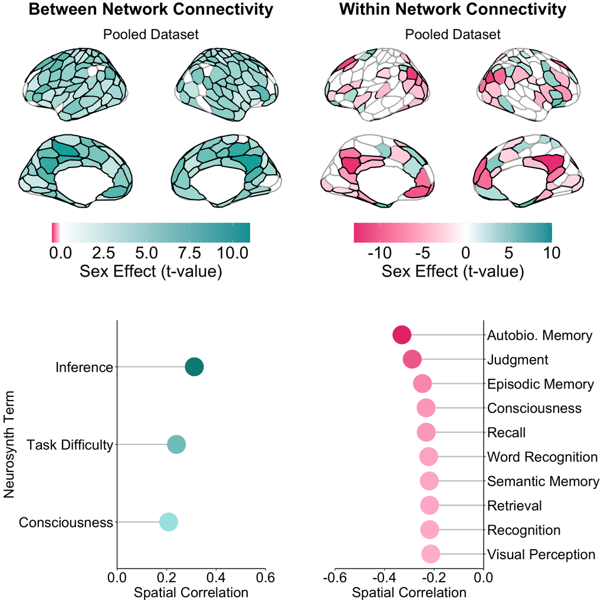

```r
neurosynth_plots_row1 <- plot_grid(BNC_pooled_tvalue_plot, WNC_pooled_tvalue_plot, ncol = 2)
neurosynth_plots_row2 <- plot_grid(blank_space, blank_space, ncol = 2)
neurosynth_plots_row3 <- BNC_neurosynth_pooled_plot + blank_space + WNC_neurosynth_pooled_plot +
  plot_layout(widths = c(1, 0.2,  1))

plot_grid(neurosynth_plots_row1, neurosynth_plots_row2, neurosynth_plots_row3, nrow = 3, rel_heights = c(1, 0.1, 1))
```

# 3. Sex differences in network-level connectivity

Given that males exhibit greater between-network connectivity across nearly all brain regions, and females exhibit greater within-network connectivity in select regions that appear to be a part of the DMN, we examined sex differences in connectivity between and within networks.

```r
num_networks = 17
sex.main.PNC.networkpair.17 <- read.csv(sprintf("%1$s/%2$s/GAM/%3$s/%2$s_GAM_sex_maineffects_schaefer200x%4$s.csv", output_root, "PNC", "networkpair", num_networks))
sex.main.HCPD.networkpair.17 <- read.csv(sprintf("%1$s/%2$s/GAM/%3$s/%2$s_GAM_sex_maineffects_schaefer200x%4$s.csv", output_root, "HCPD", "networkpair", num_networks))
sex.main.NKI.networkpair.17 <- read.csv(sprintf("%1$s/%2$s/GAM/%3$s/%2$s_GAM_sex_maineffects_schaefer200x%4$s.csv", output_root, "NKI", "networkpair", num_networks))
sex.main.HBN.networkpair.17 <- read.csv(sprintf("%1$s/%2$s/GAM/%3$s/%2$s_GAM_sex_maineffects_schaefer200x%4$s.csv", output_root, "HBN", "networkpair", num_networks))
sex.main.all_datasets.networkpair.17 <- read.csv(sprintf("%1$s/%2$s/GAM/%3$s/%2$s_GAM_sex_maineffects_schaefer200x%4$s.csv", output_root, "all_datasets", "networkpair", num_networks))


# make two new columns identifying network 1 and network 2
sex.main.PNC.networkpair.17<- sex.main.PNC.networkpair.17%>%
  mutate(network1 = str_extract(region, "[[:alpha:]]+"), network2=str_extract(region, "(?<=_).*"))
sex.main.HCPD.networkpair.17<- sex.main.HCPD.networkpair.17%>%
  mutate(network1 = str_extract(region, "[[:alpha:]]+"), network2=str_extract(region, "(?<=_).*"))
sex.main.NKI.networkpair.17<- sex.main.NKI.networkpair.17%>%
  mutate(network1 = str_extract(region, "[[:alpha:]]+"), network2=str_extract(region, "(?<=_).*"))
sex.main.HBN.networkpair.17<- sex.main.HBN.networkpair.17%>%
  mutate(network1 = str_extract(region, "[[:alpha:]]+"), network2=str_extract(region, "(?<=_).*"))
sex.main.all_datasets.networkpair.17<- sex.main.all_datasets.networkpair.17%>%
  mutate(network1 = str_extract(region, "[[:alpha:]]+"), network2=str_extract(region, "(?<=_).*"))

# fdr correction on non-duplicated pairs only and sorts pairs
sex.main.PNC.networkpair.17<- prep_networkpair_df(sex.main.PNC.networkpair.17, "networkpair", "sex", "PNC")
```

```
## [1] "PNC: 76 regions (49.67 percent) show a significant association between networkpair and sex"
```

```r
sex.main.HCPD.networkpair.17<- prep_networkpair_df(sex.main.HCPD.networkpair.17,  "networkpair", "sex", "HCPD")
```

```
## [1] "HCPD: 43 regions (28.1 percent) show a significant association between networkpair and sex"
```

```r
sex.main.NKI.networkpair.17<- prep_networkpair_df(sex.main.NKI.networkpair.17,  "networkpair", "sex", "NKI")
```

```
## [1] "NKI: 6 regions (3.92 percent) show a significant association between networkpair and sex"
```

```r
sex.main.HBN.networkpair.17<- prep_networkpair_df(sex.main.HBN.networkpair.17,  "networkpair", "sex", "HBN")
```

```
## [1] "HBN: 31 regions (20.26 percent) show a significant association between networkpair and sex"
```

```r
sex.main.all_datasets.networkpair.17<- prep_networkpair_df(sex.main.all_datasets.networkpair.17,  "networkpair", "sex", "All datasets")
```

```
## [1] "All datasets: 95 regions (62.09 percent) show a significant association between networkpair and sex"
```

```r
#range(sex.main.PNC.networkpair.17$GAM.cov.tvalue)
#range(sex.main.HCPD.networkpair.17$GAM.cov.tvalue)
#range(sex.main.NKI.networkpair.17$GAM.cov.tvalue)
#range(sex.main.HBN.networkpair.17$GAM.cov.tvalue)
#range(sex.main.all_datasets.networkpair.17$GAM.cov.tvalue)
```

```r
# plot each dataset
networkpair_PNC <- annotate_figure(
  make_networkpair17_plot(sex.main.PNC.networkpair.17, dataset = "PNC", ylim1 = -10, ylim2 = 10, fontsize = 12, fontsize_label = 4))

networkpair_HCPD <- annotate_figure(
  make_networkpair17_plot(sex.main.HCPD.networkpair.17, dataset = "HCP-D", ylim1 = -10, ylim2 = 10, fontsize = 12, fontsize_label = 4))

networkpair_NKI <- annotate_figure(
  make_networkpair17_plot(sex.main.NKI.networkpair.17, dataset = "NKI", ylim1 = -10, ylim2 = 10, fontsize = 12, fontsize_label = 4))

networkpair_HBN <- annotate_figure(
  make_networkpair17_plot(sex.main.HBN.networkpair.17, dataset = "HBN", ylim1 = -10, ylim2 = 10, fontsize = 12, fontsize_label = 4))

networkpair_all_datasets_plot <- annotate_figure(
  make_networkpair17_plot(sex.main.all_datasets.networkpair.17, dataset = "Pooled Dataset", ylim1 = -10, ylim2 = 10, fontsize = 12, fontsize_label = 4))

combined_networkpair_temp_plots <- plot_grid(
  networkpair_PNC,
  networkpair_HCPD,
  networkpair_NKI,
  networkpair_HBN,
  ncol = 2
)


# legend
ylim1 = -10
ylim2 = 10
p <- ggplot() +
    geom_brain(data = sex.main.HBN.BNC, atlas = schaefer17_200,
               mapping=aes(fill=GAM.cov.tvalue),
               show.legend=TRUE) +
     scale_fill_gradientn(colours = c("#EE4684", "white", "#009EA4"),
                          values = scales::rescale(c(ylim1, 0, ylim2)), limits = c(ylim1, ylim2), oob = squish, na.value = "white") +
    theme_void()  +
    theme(legend.title = element_blank(),
          legend.text = element_text(size = 24),
        legend.position = "bottom",
        legend.box = "horizontal",
        legend.key.height = unit(1, 'cm'),
        legend.key.width = unit(3, 'cm'),
        plot.margin = unit(c(0, 1, 0, -0.5), "cm"))

legend <- get_legend(p)
```

```r
# overlap of datasets:
df_list_networkpair <- list(
  PNC  = sex.main.PNC.networkpair.17[, c("region", "Anova.cov.pvalue.fdr")] |> rename(p_PNC = Anova.cov.pvalue.fdr),
  HCPD = sex.main.HCPD.networkpair.17[, c("region", "Anova.cov.pvalue.fdr")] |> rename(p_HCPD = Anova.cov.pvalue.fdr),
  NKI  = sex.main.NKI.networkpair.17[,  c("region", "Anova.cov.pvalue.fdr")] |> rename(p_NKI = Anova.cov.pvalue.fdr),
  HBN  = sex.main.HBN.networkpair.17[,  c("region", "Anova.cov.pvalue.fdr")] |> rename(p_HBN = Anova.cov.pvalue.fdr)
)

sex.main.overlap.networkpair <- Reduce(function(x, y) full_join(x, y, by = "region"), df_list_networkpair)

sex.main.overlap.networkpair <- sex.main.overlap.networkpair %>%
  mutate(
    signif_count = rowSums(across(starts_with("p_")) < 0.05, na.rm = TRUE),
    signif_count_factor = factor(
      signif_count,
      levels = 0:4,
      labels = c("0", "1", "2", "3", "4")
    ),
    signif_greater_than_one = ifelse(signif_count > 1, "1", "0")
  )

sex.main.overlap.networkpair <- sex.main.overlap.networkpair %>%
  mutate(
    network1 = str_extract(region, "^[[:alpha:]]+"),
    network2 = str_extract(region, "(?<=_).*")
  )


# overlap legend
legend_plot <- ggplot(data.frame(overlap = factor(names(count_colors_legend),
                                                  levels = names(count_colors_legend))),
                      aes(x = overlap, fill = overlap)) +
  geom_bar() +
  scale_fill_manual(values = count_colors_legend,
                    guide = guide_legend(direction = "horizontal",
                                         label.position = "bottom",
                                         override.aes = list(colour = "black", size = 1))) +
  theme_void() +
  theme(
    legend.title = element_blank(),
    legend.text  = element_text(size = 18),
    legend.key.size = unit(1.3, "cm"),
    legend.position = "bottom"
  )

overlap_legend <- get_legend(legend_plot)
networkpair_overlap_plot <-  annotate_figure(plot_networkpair_overlap(sex.main.overlap.networkpair), top = text_grob("Overlap of Significant Effects Across Datasets", size = 24, x = 0.55))
```

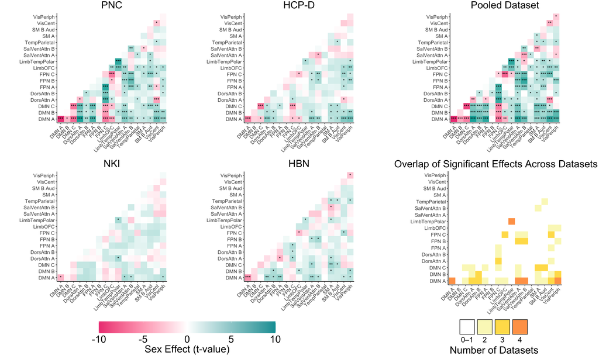

```r
networkpair_col1 <- annotate_figure(
  plot_grid(
    combined_networkpair_temp_plots,
    legend,
    nrow = 2, rel_heights = c(1, 0.1)  ),
  bottom = text_grob("Sex Effect (t-value)", size = 24, y = 1)
)



networkpair_col2 <- annotate_figure(plot_grid(networkpair_all_datasets_plot, networkpair_overlap_plot, overlap_legend, nrow = 3, rel_heights = c(1, 1, 0.2)),
                                     bottom = text_grob("Number of Datasets", size = 24, y = 0.1))



networkpair_col2 <- plot_grid(networkpair_all_datasets_plot, networkpair_overlap_plot, nrow = 2)
overlap_legend_layout <- plot_grid(blank_space, overlap_legend, ncol = 2, rel_widths = c(0.08, 1))
overlap_legend_layout <- plot_grid(overlap_legend_layout, blank_space, nrow = 2, rel_heights = c(1, 0.1))

networkpair_col2 <- annotate_figure(plot_grid(networkpair_col2, overlap_legend_layout, nrow = 2, rel_heights = c(1, 0.1)),  bottom = text_grob("Number of Datasets", size = 24, y = 0.9, x = 0.54))

plot_grid(networkpair_col1, blank_space, networkpair_col2, blank_space, ncol = 4, rel_widths = c(2,0.1, 1, 0.1))
```

Network enrichment significance testing showed that default mode subnetwork A within-network connectivity is indeed more enriched in females than in males in all 4 datasets.  
- may need to run this for all datasets

```r
PNC_NEST_DMNA <- readRDS("/cbica/projects/network_replication/covariate_analyses/sex_diff/output/PNC/NEST/WNC/NEST_DefaultA_WNC.RData")
HCPD_NEST_DMNA <- readRDS("/cbica/projects/network_replication/covariate_analyses/sex_diff/output/HCPD/NEST/WNC/NEST_DefaultA_WNC.RData")
NKI_NEST_DMNA <- readRDS("/cbica/projects/network_replication/covariate_analyses/sex_diff/output/NKI/NEST/WNC/NEST_DefaultA_WNC.RData")
HBN_NEST_DMNA <- readRDS("/cbica/projects/network_replication/covariate_analyses/sex_diff/output/HBN/NEST/WNC/NEST_DefaultA_WNC.RData")

NEST_results <- data.frame(
  Dataset = c("PNC", "HCP-D", "NKI", "HBN"),
  `NEST p-value` = c(
    as.numeric(PNC_NEST_DMNA$pval),
    as.numeric(HCPD_NEST_DMNA$pval),
    as.numeric(NKI_NEST_DMNA$pval),
    as.numeric(HBN_NEST_DMNA$pval)
  )
)

NEST_results %>%
  kbl(format = "html", align = "lcccc", digits = 4,
      caption = "Network enrichment significance testing for Default Mode Subnetwork A (female > male).") %>%
  add_header_above(c(" " = 1, "Default Mode Subnetwork A" = 1), bold = TRUE) %>%
  kable_styling(full_width = FALSE, position = "center") %>%
  kable_classic(full_width = FALSE, html_font = "Arial") %>%
  row_spec(0:nrow(NEST_results), extra_css = "line-height: 0.7;") %>%
  column_spec(2, background = "gray90", include_thead = TRUE)
```

Network enrichment significance testing for Default Mode Subnetwork A (female > male).

| Dataset | Default Mode Subnetwork A NEST.p.value |
| --- | --- |
| PNC | 0.0007 |
| HCP-D | 0.0148 |
| NKI | 0.0009 |
| HBN | 0.0030 |

```r
PNC_NEST_LimbA <- readRDS("/cbica/projects/network_replication/covariate_analyses/sex_diff/output/PNC/NEST/WNC/NEST_LimbicA_TempPole_WNC.RData")
HCPD_NEST_LimbA <- readRDS("/cbica/projects/network_replication/covariate_analyses/sex_diff/output/HCPD/NEST/WNC/NEST_LimbicA_TempPole_WNC.RData")
NKI_NEST_LimbA <- readRDS("/cbica/projects/network_replication/covariate_analyses/sex_diff/output/NKI/NEST/WNC/NEST_LimbicA_TempPole_WNC.RData")
#HBN_NEST_LimbA <- readRDS("/cbica/projects/network_replication/covariate_analyses/sex_diff/output/HBN/NEST/WNC/NEST_LimbicA_TempPole_WNC.RData")

NEST_results <- data.frame(
  Dataset = c("PNC", "HCP-D", "NKI", "HBN"),
  `NEST p-value` = c(
    as.numeric(PNC_NEST_LimbA$pval),
    as.numeric(HCPD_NEST_LimbA$pval),
    as.numeric(NKI_NEST_LimbA$pval),
    NA
    #as.numeric(HBN_NEST_LimbA$pval)
  )
)

NEST_results %>%
  kbl(format = "html", align = "lcccc", digits = 4,
      caption = "Network enrichment significance testing for LimbicA Temporal Pole (male > female).") %>%
  add_header_above(c(" " = 1, "Limbic Subnetwork A" = 1), bold = TRUE) %>%
  kable_styling(full_width = FALSE, position = "center") %>%
  kable_classic(full_width = FALSE, html_font = "Arial") %>%
  row_spec(0:nrow(NEST_results), extra_css = "line-height: 0.7;") %>%
  column_spec(2, background = "gray90", include_thead = TRUE)
```

Network enrichment significance testing for LimbicA Temporal Pole (male > female).

| Dataset | Limbic Subnetwork A NEST.p.value |
| --- | --- |
| PNC | 0.0005 |
| HCP-D | 0.0140 |
| NKI | 0.0027 |
| HBN | NA |

# 4. Sex differences in edge-level connectivity vary with hierarchical span of functional connections

```r
# edge gam output
sex.main.PNC.edge <- read.csv(sprintf("%1$s/%2$s/GAM/%3$s/%2$s_GAM_sex_maineffects_schaefer200x17.csv", output_root, "PNC", "edge"))
sex.main.HCPD.edge <- read.csv(sprintf("%1$s/%2$s/GAM/%3$s/%2$s_GAM_sex_maineffects_schaefer200x17.csv", output_root, "HCPD", "edge"))
sex.main.NKI.edge <- read.csv(sprintf("%1$s/%2$s/GAM/%3$s/%2$s_GAM_sex_maineffects_schaefer200x17.csv", output_root, "NKI", "edge"))
sex.main.HBN.edge <- read.csv(sprintf("%1$s/%2$s/GAM/%3$s/%2$s_GAM_sex_maineffects_schaefer200x17.csv", output_root, "HBN", "edge"))
sex.main.all_datasets.edge <- read.csv(sprintf("%1$s/%2$s/GAM/%3$s/%2$s_GAM_sex_maineffects_schaefer200x17.csv", output_root, "all_datasets", "edge"))

# load vector of differences in S-A rank between the 2 regions connecting each edge
SA.diff <- read.csv("/cbica/projects/network_replication/atlases/edge/SA.diff_schaefer200x17.csv")

# make df for plotting (and do FDR correction)
double.PNC <- make_double_df(sex.main.PNC.edge, "edge", "sex", "PNC")
```

```
## [1] "PNC: 6947 regions (34.91 percent) show a significant association between edge and sex"
```

```r
double.HCPD <- make_double_df(sex.main.HCPD.edge, "edge", "sex", "HCPD")
```

```
## [1] "HCPD: 3341 regions (16.79 percent) show a significant association between edge and sex"
```

```r
double.NKI <- make_double_df(sex.main.NKI.edge, "edge", "sex", "NKI")
```

```
## [1] "NKI: 571 regions (2.87 percent) show a significant association between edge and sex"
```

```r
double.HBN <- make_double_df(sex.main.HBN.edge, "edge", "sex", "HBN")
```

```
## [1] "HBN: 1960 regions (9.85 percent) show a significant association between edge and sex"
```

```r
double.all_datasets <- make_double_df(sex.main.all_datasets.edge, "edge", "sex", "All datasets")
```

```
## [1] "All datasets: 9552 regions (48 percent) show a significant association between edge and sex"
```

```r
# load spin test results
PNC_edges_spin <- readRDS(sprintf("%1$s/%2$s/spin_test/edge/SA_edges_schaefer200x17_spin_test_results.RData", output_root, "PNC"))
HCPD_edges_spin <- readRDS(sprintf("%1$s/%2$s/spin_test/edge/SA_edges_schaefer200x17_spin_test_results.RData", output_root, "HCPD"))
NKI_edges_spin <- readRDS(sprintf("%1$s/%2$s/spin_test/edge/SA_edges_schaefer200x17_spin_test_results.RData", output_root, "NKI"))
HBN_edges_spin <- readRDS(sprintf("%1$s/%2$s/spin_test/edge/SA_edges_schaefer200x17_spin_test_results.RData", output_root, "HBN"))
all_datasets_edges_spin <- readRDS(sprintf("%1$s/%2$s/spin_test/edge/SA_edges_schaefer200x17_spin_test_results.RData", output_root, "all_datasets"))
```

We modeled the sex-effect map (t-values) across edges using tensor product smooth:

$$edge.sex.effect \sim te(SArank_{parcel1}, SArank_{parcel2})$$

We assessed significance with a spin test that preserves spatial autocorrelation by rotating the S-A axis and recomputing model fit statistics (R2). The spin test evaluates whether the 2D tensor smooth linking sex effects to S–A axis ranks is stronger than expected given spatial autocorrelation.

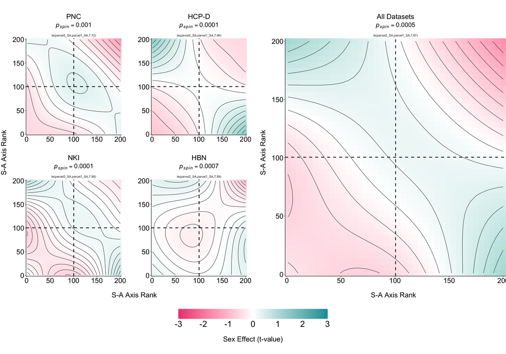

```r
# plot surfaces
PNC_surf_plot <- make_surface_plot(double.PNC, dataset = "PNC", measure = "GAM.cov.tvalue", ylim1 = -3, ylim2  = 3,
                                   p_label = bquote(italic(p[spin]) == .(format(round(PNC_edges_spin$p_values$R2, 3), scientific = FALSE))))
HCPD_surf_plot <-  make_surface_plot(double.HCPD, dataset = "HCP-D", measure = "GAM.cov.tvalue", ylim1 = -3, ylim2  = 3,
                                   p_label = bquote(italic(p[spin]) == .(format(round(HCPD_edges_spin$p_values$R2, 4), scientific = FALSE))))
NKI_surf_plot <-  make_surface_plot(double.NKI, dataset = "NKI", measure = "GAM.cov.tvalue", ylim1 = -3, ylim2  = 3,
                                   p_label = bquote(italic(p[spin]) == .(format(round(NKI_edges_spin$p_values$R2, 4), scientific = FALSE))))
HBN_surf_plot <-  make_surface_plot(double.HBN, dataset = "HBN", measure = "GAM.cov.tvalue", ylim1 = -3, ylim2  = 3,
                                   p_label = bquote(italic(p[spin]) == .(format(round(HBN_edges_spin$p_values$R2, 4), scientific = FALSE))))
row1 <- plot_grid(PNC_surf_plot, blank_space, HCPD_surf_plot, ncol = 3, rel_widths = c(1, 0.1, 1))
row2 <- plot_grid(NKI_surf_plot, blank_space, HBN_surf_plot, ncol = 3, rel_widths = c(1, 0.1, 1))
combined_surf_plots <- plot_grid(row1, blank_space, row2, ncol = 1, nrow = 3, rel_heights = c(1, 0.1, 1))
combined_surf_plots <- annotate_figure(combined_surf_plots,
                                 left = text_grob("S-A Axis Rank", size = 20, x = 0.5, rot = 90),
                                 bottom = text_grob("S-A Axis Rank", size = 20, x = 0.53, y = -0.5))

all_datasets_surf_plot <-  make_surface_plot(double.all_datasets, dataset = "All Datasets", measure = "GAM.cov.tvalue", ylim1 = -3, ylim2  = 3,
                                   p_label = bquote(italic(p[spin]) == .(format(round(all_datasets_edges_spin$p_values$R2, 4), scientific = FALSE))))
all_datasets_surf_plot <- annotate_figure(all_datasets_surf_plot,
                                 left = text_grob("S-A Axis Rank", size = 20, x = 0.5, rot = 90),
                                 bottom = text_grob("S-A Axis Rank", size = 20, x = 0.53, y = -0.5))
# make legend
ylim1 = -3
ylim2 = 3
g2 <- gam(GAM.cov.tvalue ~ te(parcel2_SA,parcel1_SA,k=3), data = double.PNC)

surface.plot.fig <- gg_tensor(g2) + theme_classic() +
    theme(
      axis.title.x=element_blank(),
      axis.title.y=element_blank(),
      axis.line = element_line(color = "black"),
      axis.text=element_text(size=24, color = "black")) +
     scale_fill_gradientn(colours = c("#EE4684", "white", "#009EA4"),
                          values = scales::rescale(c(ylim1, 0, ylim2)), limits = c(ylim1, ylim2), oob = squish, na.value = "white") +     geom_vline(xintercept = mean(range(double.PNC$parcel1.SA.vec)),
               linetype='dashed',size=1) +
    geom_hline(yintercept = mean(range(double.PNC$parcel1.SA.vec)),
               linetype='dashed',size=1) +
    theme(legend.position='bottom',
          legend.key.height = unit(1, 'cm'),
          legend.key.width = unit(3, 'cm'),
          legend.title = element_blank(),
          legend.text = element_text(size=24),
          strip.background = element_blank(),
          plot.margin = margin(0, 0, 0, 0, "cm"),
          plot.title = element_text(size=24, hjust=0.5))

legend <- get_legend(surface.plot.fig)


# combine plots
combined_surf_plots <- plot_grid(combined_surf_plots, blank_space, all_datasets_surf_plot, ncol = 3, rel_widths = (c(1, 0.05, 1)))

final_surf_plots <- plot_grid(blank_space, combined_surf_plots, legend, nrow = 3, rel_heights = c(0.05, 1, 0.2))
annotate_figure(final_surf_plots,
                bottom = text_grob("Sex Effect (t-value)", size = 20, x = 0.5, y = 2))
```

Sex effects at the edge-level appear to be distributed hierarchically, with males showing stronger connectivity in edges connecting regions across the S-A axis and in the middle of the axis (i.e. association-sensorimotor and middle-middle ranking regions) and females showing higher connectivity between similarly ranked regions (i.e. association-association and sensorimotor-sensorimotor regions). Connectivity in males appear to be more integrative, whereas females exhibit greater segregation.

# extra

- To quantify whether pfactor and sex affect similar edges/networks: topographical overlap of effects
- To test whether one map statistically predicts another: spatial covariance structure
- Goal: Does the pattern of connections that differ by pfactor resemble the pattern that differs by sex?

```r
# edge gam output
clinical.main.all_datasets.edge <- read.csv(sprintf("%1$s/%2$s/GAM/%3$s/%2$s_GAM_clinical_maineffects_schaefer200x17.csv", output_root, "all_datasets", "edge"))
clinical.main.all_datasets.edge_pfactor <- clinical.main.all_datasets.edge %>% filter(covariate == "p_factor_mcelroy_harmonized_all_samples") %>% rename(GAM.cov.pvalue = p_value, GAM.cov.tvalue = t_value)
clinical.main.all_datasets.edge_int <- clinical.main.all_datasets.edge %>% filter(covariate == "internalizing_mcelroy_harmonized_all_samples") %>% rename(GAM.cov.pvalue = p_value, GAM.cov.tvalue = t_value)
clinical.main.all_datasets.edge_ext <- clinical.main.all_datasets.edge %>% filter(covariate == "externalizing_mcelroy_harmonized_all_samples") %>% rename(GAM.cov.pvalue = p_value, GAM.cov.tvalue = t_value)
clinical.main.all_datasets.edge_att <- clinical.main.all_datasets.edge %>% filter(covariate == "attention_mcelroy_harmonized_all_samples") %>% rename(GAM.cov.pvalue = p_value, GAM.cov.tvalue = t_value)

clinical.main.all_datasets.edge_sex <- clinical.main.all_datasets.edge %>% filter(covariate == "sex") %>% rename(GAM.cov.pvalue = p_value, GAM.cov.tvalue = t_value)


# make df for plotting (and do FDR correction)
double.pfactor <- make_double_df(clinical.main.all_datasets.edge_pfactor, "edge", "pfactor", "All datasets")
```

```
## [1] "All datasets: 1 regions (0.01 percent) show a significant association between edge and pfactor"
```

```r
double.int <- make_double_df(clinical.main.all_datasets.edge_int, "edge", "internalizing", "All datasets")
```

```
## [1] "All datasets: 1 regions (0.01 percent) show a significant association between edge and internalizing"
```

```r
double.ext <- make_double_df(clinical.main.all_datasets.edge_ext, "edge", "externalizing", "All datasets")
```

```
## [1] "All datasets: 0 regions (0 percent) show a significant association between edge and externalizing"
```

```r
double.att <- make_double_df(clinical.main.all_datasets.edge_att, "edge", "attention", "All datasets")
```

```
## [1] "All datasets: 3 regions (0.02 percent) show a significant association between edge and attention"
```

```r
double.sex <- make_double_df(clinical.main.all_datasets.edge_sex, "edge", "sex", "All datasets")
```

```
## [1] "All datasets: 7717 regions (38.78 percent) show a significant association between edge and sex"
```

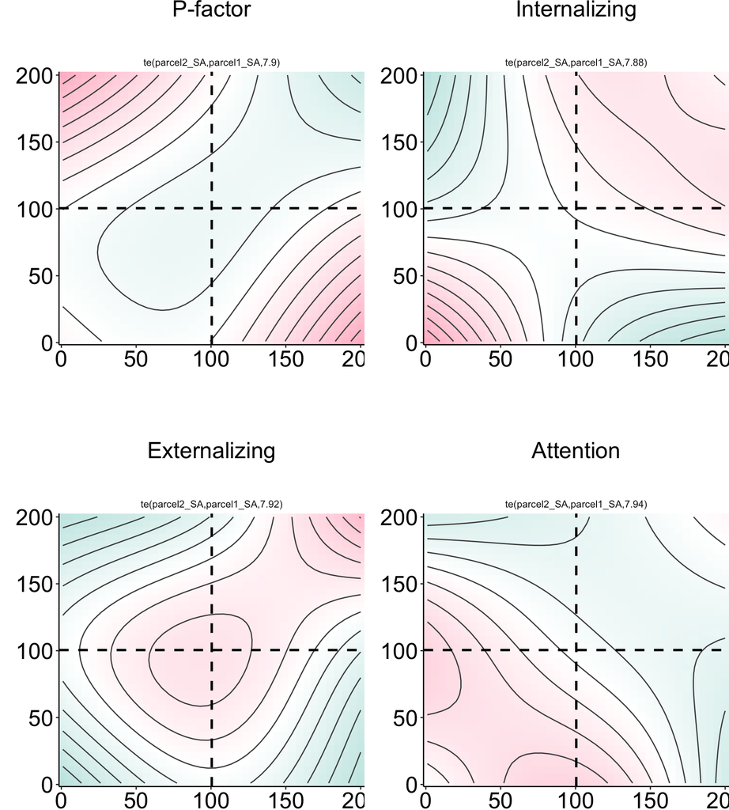

```r
pfactor_surf <- make_surface_plot(double.pfactor, dataset = "P-factor", measure = "GAM.cov.tvalue", ylim1 = -2, ylim2  = 2,
                                   p_label = "")

int_surf <- make_surface_plot(double.int, dataset = "Internalizing", measure = "GAM.cov.tvalue", ylim1 = -2, ylim2  = 2,
                                   p_label = "")

ext_surf <- make_surface_plot(double.ext, dataset = "Externalizing", measure = "GAM.cov.tvalue", ylim1 = -2, ylim2  = 2,
                                   p_label = "")
att_surf <- make_surface_plot(double.att, dataset = "Attention", measure = "GAM.cov.tvalue", ylim1 = -2, ylim2  = 2,
                                   p_label = "")

row1_clinical <- plot_grid(pfactor_surf, int_surf, ncol=2)
row2_clinical <- plot_grid(ext_surf, att_surf, ncol=2)
plot_grid(row1_clinical, blank_space, row2_clinical, nrow = 3, rel_heights = c(1, 0.2, 1))
```

# Supplement? Age-by-sex interaction across ALL datasets

- WNC in 11 regions (5%; schaefer200x7) and 22 regions (11%; schafer200x17) has some age-by-sex effects when datasets are pooled.
- network-pair connectivity also has some significant age-by-sex interactions

```r
GBC_schaefer7 <- read.csv("/cbica/projects/network_replication/covariate_analyses/sex_diff/output/all_datasets/GAM/GBC/all_datasets_GAM_agebysex_interaction_schaefer200x7.csv")
GBC_schaefer7 <- sig.effects.all_datasets(GBC_schaefer7, "GBC", "sex", "all_datasets 7 networks", "GAM.int.pvalue", "GAM.int.Fvalue")
```

```
## [1] "all_datasets 7 networks: 0 regions (0 percent) show a significant association between GBC and sex"
```

```r
GBC_schaefer17 <- read.csv("/cbica/projects/network_replication/covariate_analyses/sex_diff/output/all_datasets/GAM/GBC/all_datasets_GAM_agebysex_interaction_schaefer200x17.csv")
GBC_schaefer17 <- sig.effects.all_datasets(GBC_schaefer17, "GBC", "sex", "all_datasets 17 networks", "GAM.int.pvalue", "GAM.int.Fvalue")
```

```
## [1] "all_datasets 17 networks: 0 regions (0 percent) show a significant association between GBC and sex"
```

```r
BNC_schaefer7 <- read.csv("/cbica/projects/network_replication/covariate_analyses/sex_diff/output/all_datasets/GAM/BNC/all_datasets_GAM_agebysex_interaction_schaefer200x7.csv")
BNC_schaefer7 <- sig.effects.all_datasets(BNC_schaefer7, "BNC", "sex", "all_datasets 7 networks", "GAM.int.pvalue", "GAM.int.Fvalue")
```

```
## [1] "all_datasets 7 networks: 0 regions (0 percent) show a significant association between BNC and sex"
```

```r
BNC_schaefer17 <- read.csv("/cbica/projects/network_replication/covariate_analyses/sex_diff/output/all_datasets/GAM/BNC/all_datasets_GAM_agebysex_interaction_schaefer200x17.csv")
BNC_schaefer17 <- sig.effects.all_datasets(BNC_schaefer17, "BNC", "sex", "all_datasets 17 networks", "GAM.int.pvalue", "GAM.int.Fvalue")
```

```
## [1] "all_datasets 17 networks: 0 regions (0 percent) show a significant association between BNC and sex"
```

```r
WNC_schaefer7 <- read.csv("/cbica/projects/network_replication/covariate_analyses/sex_diff/output/all_datasets/GAM/WNC/all_datasets_GAM_agebysex_interaction_schaefer200x7.csv")
WNC_schaefer7 <- sig.effects.all_datasets(WNC_schaefer7, "WNC", "sex", "all_datasets 7 networks", "GAM.int.pvalue", "GAM.int.Fvalue")
```

```
## [1] "all_datasets 7 networks: 11 regions (5.5 percent) show a significant association between WNC and sex"
```

```r
WNC_schaefer17 <- read.csv("/cbica/projects/network_replication/covariate_analyses/sex_diff/output/all_datasets/GAM/WNC/all_datasets_GAM_agebysex_interaction_schaefer200x17.csv")
WNC_schaefer17 <- sig.effects.all_datasets(WNC_schaefer17, "WNC", "sex", "all_datasets 17 networks", "GAM.int.pvalue", "GAM.int.Fvalue")
```

```
## [1] "all_datasets 17 networks: 22 regions (11 percent) show a significant association between WNC and sex"
```

```r
#WNC_schaefer17 %>% arrange(desc(int_sig_effect))

netpair_schaefer7 <- read.csv("/cbica/projects/network_replication/covariate_analyses/sex_diff/output/all_datasets/GAM/networkpair/all_datasets_GAM_agebysex_interaction_schaefer200x7.csv")
netpair_schaefer7 <- sig.effects.all_datasets(netpair_schaefer7, "netpair", "sex", "all_datasets 7 networks", "GAM.int.pvalue", "GAM.int.Fvalue")
```

```
## [1] "all_datasets 7 networks: 2 regions (7.14 percent) show a significant association between netpair and sex"
```

```r
netpair_schaefer17 <- read.csv("/cbica/projects/network_replication/covariate_analyses/sex_diff/output/all_datasets/GAM/networkpair/all_datasets_GAM_agebysex_interaction_schaefer200x17.csv")
netpair_schaefer17 <- sig.effects.all_datasets(netpair_schaefer17, "netpair", "sex", "all_datasets 17 networks", "GAM.int.pvalue", "GAM.int.Fvalue")
```

```
## [1] "all_datasets 17 networks: 10 regions (6.54 percent) show a significant association between netpair and sex"
```

```r
#netpair_schaefer17 %>% arrange(desc(int_sig_effect))
```

- didn’t run age-by-sex fits yet but these are the regions

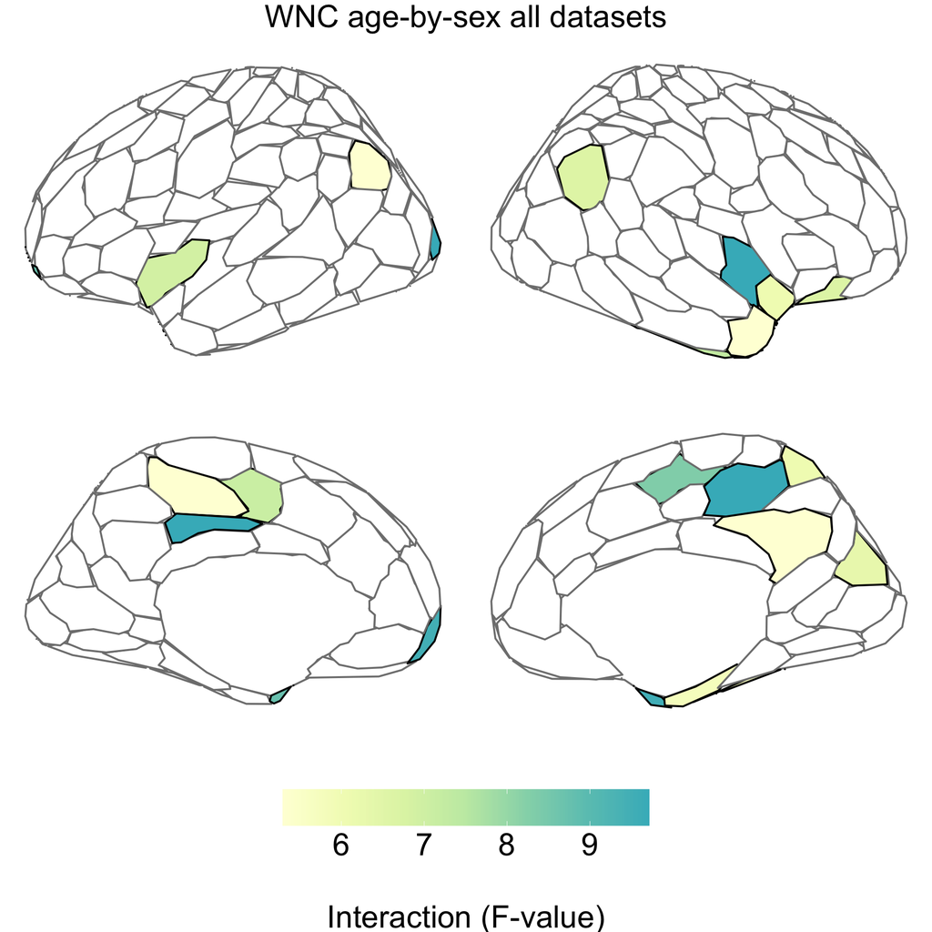

```r
WNC_schaefer17$region <- paste0("17", WNC_schaefer17$region)
sex.int.all_dataset.WNC_lh <- plot_cortex_int(WNC_schaefer17, hemi = "left", measure = "int_sig_effect", ylim1 = 1, ylim2 = 9, atlas = "schaefer17_200")
sex.int.all_dataset.WNC_rh <- plot_cortex_int(WNC_schaefer17, hemi = "right", measure = "int_sig_effect", ylim1 = 1, ylim2 = 9, atlas = "schaefer17_200")

ylim1 = 1
ylim2 = 9
p <- ggplot() +
    geom_brain(data = WNC_schaefer17, atlas = schaefer17_200,
               mapping=aes(fill=int_sig_effect, colour=significant_status, size=I(0.7)),
               show.legend=TRUE) +
    scale_fill_paletteer_c("ggthemes::Blue-Green Sequential", na.value = "white") +
    scale_colour_manual(values = c("Sig" = "black", "Nonsig" = "grey50")) +
    theme_void() +
    theme(legend.title = element_blank(),
          legend.text = element_text(size = 24),
        legend.position = "bottom",
        legend.box = "horizontal",
        legend.key.height = unit(1, 'cm'),
        legend.key.width = unit(2, 'cm'),
        plot.margin = unit(c(0, 1, 0, -0.5), "cm")) + guides(color = "none")


legend <- get_legend(p)
blank_space <- ggplot() + theme_void()

annotate_figure(
  plot_grid(
    annotate_figure(
      plot_grid(
        sex.int.all_dataset.WNC_lh,
        sex.int.all_dataset.WNC_rh,
        ncol = 2
      ),
      top = text_grob("WNC age-by-sex all datasets", size = 24)
    ),
    legend,
    ncol = 1,
    rel_heights = c(1, 0.2)
  ),
  bottom = text_grob("Interaction (F-value)", size = 24)
)
```

```r
 print(WNC_schaefer17 %>% arrange(desc(int_sig_effect)) %>% filter(significant_status == "Sig") %>% pull(region))
```

```
##  [1] "17Networks_RH_SalVentAttnA_Ins_2"    "17Networks_RH_SalVentAttnA_ParMed_2"
##  [3] "17Networks_RH_LimbicA_TempPole_1"    "17Networks_RH_SomMotA_3"
##  [5] "17Networks_LH_VisCent_ExStr_3"       "17Networks_LH_DefaultA_pCunPCC_2"
##  [7] "17Networks_LH_DefaultA_PFCm_2"       "17Networks_RH_LimbicA_TempPole_2"
##  [9] "17Networks_LH_LimbicA_TempPole_3"    "17Networks_RH_LimbicB_OFC_2"
## [11] "17Networks_RH_DefaultA_IPL_1"        "17Networks_RH_VisPeri_ExStrSup_2"
## [13] "17Networks_LH_SomMotA_1"             "17Networks_LH_SalVentAttnA_Ins_1"
## [15] "17Networks_RH_DorsAttnB_PostC_3"     "17Networks_RH_SalVentAttnA_Ins_1"
## [17] "17Networks_RH_LimbicA_TempPole_3"    "17Networks_RH_LimbicA_TempPole_4"
## [19] "17Networks_LH_SalVentAttnA_ParMed_1" "17Networks_RH_DefaultA_pCunPCC_1"
## [21] "17Networks_RH_DefaultB_AntTemp_1"    "17Networks_LH_DefaultA_IPL_1"
```

```r
 print(netpair_schaefer17 %>% arrange(desc(int_sig_effect)) %>% filter(significant_status == "Sig") %>% pull(region))
```

```
##  [1] "defaultB_frontoparietalControlC"
##  [2] "salienceVentralAttentionA_somatomotorBAuditory"
##  [3] "salienceVentralAttentionA_visualCentral"
##  [4] "defaultA_frontoparietalControlC"
##  [5] "limbicTemporopolar_limbicTemporopolar"
##  [6] "frontoparietalControlC_somatomotorBAuditory"
##  [7] "defaultA_defaultA"
##  [8] "salienceVentralAttentionB_visualCentral"
##  [9] "frontoparietalControlA_frontoparietalControlC"
## [10] "dorsalAttentionA_frontoparietalControlC"
```

# Clinical measures exploration - just fyi

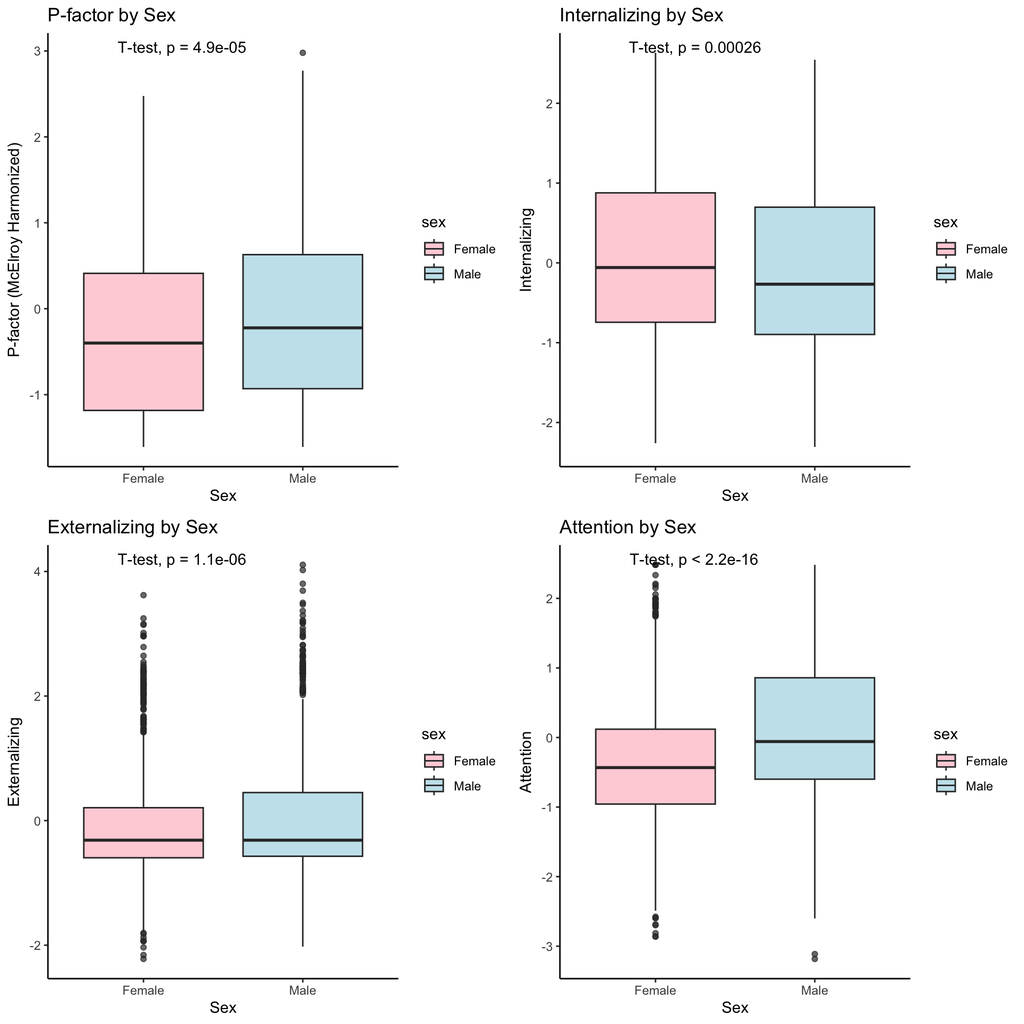

```r
PNC_config_data <- fromJSON(file=sprintf("/cbica/projects/network_replication/covariate_analyses/sex_diff/code/config/config_%1$s.json", "PNC"))
HCPD_config_data <- fromJSON(file=sprintf("/cbica/projects/network_replication/covariate_analyses/sex_diff/code/config/config_%1$s.json", "HCPD"))
NKI_config_data <- fromJSON(file=sprintf("/cbica/projects/network_replication/covariate_analyses/sex_diff/code/config/config_%1$s.json", "NKI"))
HBN_config_data <- fromJSON(file=sprintf("/cbica/projects/network_replication/covariate_analyses/sex_diff/code/config/config_%1$s.json", "HBN"))

###################
# Define functions
###################
# load pfactor data and merge with demographics
load_pfactor_data <- function(file_path) {
  pfactor <- fread(file_path)
  pfactor <- pfactor %>% rename(sub = participant_id)
  pfactor$sub <- paste0("sub-", pfactor$sub)
  pfactor <- pfactor %>% select(sub, p_factor_mcelroy_harmonized_all_samples, internalizing_mcelroy_harmonized_all_samples, externalizing_mcelroy_harmonized_all_samples, attention_mcelroy_harmonized_all_samples)
  pfactor <- pfactor[!duplicated(pfactor), ]
  pfactor <- pfactor[complete.cases(pfactor), ]
  return(pfactor)
}

# load demographics for all datasets and combine
PNC_demographics <- read.csv(PNC_config_data$demographics, stringsAsFactors = TRUE) %>% mutate(dataset_site = "PNC") %>% select(sub, age, sex, meanFD_avgSes, dataset_site)
NKI_demographics <- read.csv(NKI_config_data$demographics, stringsAsFactors = TRUE) %>% mutate(dataset_site = "NKI") %>% select(sub, age, sex, meanFD_avgSes, dataset_site)
HBN_demographics <- read.csv(HBN_config_data$demographics, stringsAsFactors = TRUE) %>% rename(site = ses) %>% mutate(dataset_site = paste0("HBN_", site)) %>% select(sub, age, sex, meanFD_avgSes, dataset_site)

#load clinical measures
PNC_pfactor <- load_pfactor_data("/cbica/projects/network_replication/covariate_analyses/pfactor/input/PNC/sample_info/study-PNC_desc-participants.tsv")
NKI_pfactor <- load_pfactor_data("/cbica/projects/network_replication/covariate_analyses/pfactor/input/NKI/sample_info/study-NKI_desc-participants.tsv")
NKI_pfactor$sub <- gsub("sub-", "", NKI_pfactor$sub)
HBN_pfactor <- load_pfactor_data("/cbica/projects/network_replication/covariate_analyses/pfactor/input/HBN/sample_info/study-HBN_desc-participants.tsv")

PNC_demographics <- inner_join(PNC_pfactor, PNC_demographics,by = "sub")
NKI_demographics <- inner_join(NKI_pfactor, NKI_demographics,by = "sub")
HBN_demographics <- inner_join(HBN_pfactor, HBN_demographics,by = "sub")

demographics <- rbind(PNC_demographics, NKI_demographics, HBN_demographics)
# load demographics for all datasets and combine
PNC_demographics <- read.csv(PNC_config_data$demographics, stringsAsFactors = TRUE) %>% mutate(dataset_site = "PNC") %>% select(sub, age, sex, meanFD_avgSes, dataset_site)
NKI_demographics <- read.csv(NKI_config_data$demographics, stringsAsFactors = TRUE) %>% mutate(dataset_site = "NKI") %>% select(sub, age, sex, meanFD_avgSes, dataset_site)
HBN_demographics <- read.csv(HBN_config_data$demographics, stringsAsFactors = TRUE) %>% rename(site = ses) %>% mutate(dataset_site = paste0("HBN_", site)) %>% select(sub, age, sex, meanFD_avgSes, dataset_site)

#load clinical measures
PNC_pfactor <- load_pfactor_data("/cbica/projects/network_replication/covariate_analyses/pfactor/input/PNC/sample_info/study-PNC_desc-participants.tsv")
NKI_pfactor <- load_pfactor_data("/cbica/projects/network_replication/covariate_analyses/pfactor/input/NKI/sample_info/study-NKI_desc-participants.tsv")
NKI_pfactor$sub <- gsub("sub-", "", NKI_pfactor$sub)
HBN_pfactor <- load_pfactor_data("/cbica/projects/network_replication/covariate_analyses/pfactor/input/HBN/sample_info/study-HBN_desc-participants.tsv")

PNC_demographics <- inner_join(PNC_pfactor, PNC_demographics,by = "sub")
NKI_demographics <- inner_join(NKI_pfactor, NKI_demographics,by = "sub")
HBN_demographics <- inner_join(HBN_pfactor, HBN_demographics,by = "sub")

demographics <- rbind(PNC_demographics, NKI_demographics, HBN_demographics)



pfactor_plot <- ggplot(demographics, aes(x = sex, y = p_factor_mcelroy_harmonized_all_samples, fill = sex)) +
  geom_boxplot(alpha = 0.7) +
  stat_compare_means(method = "t.test") +
  labs(title = "P-factor by Sex",
       x = "Sex", y = "P-factor (McElroy Harmonized)") +
  theme_classic() +
  scale_fill_manual(values = c("pink", "lightblue"))



int_plot <- ggplot(demographics, aes(x = sex, y = internalizing_mcelroy_harmonized_all_samples, fill = sex)) +
  geom_boxplot(alpha = 0.7) +
  stat_compare_means(method = "t.test") +
  labs(title = "Internalizing by Sex",
       x = "Sex", y = "Internalizing") +
  theme_classic() +
  scale_fill_manual(values = c("pink", "lightblue"))


ext_plot <- ggplot(demographics, aes(x = sex, y = externalizing_mcelroy_harmonized_all_samples, fill = sex)) +
  geom_boxplot(alpha = 0.7) +
  stat_compare_means(method = "t.test") +
  labs(title = "Externalizing by Sex",
       x = "Sex", y = "Externalizing") +
  theme_classic() +
  scale_fill_manual(values = c("pink", "lightblue"))

att_plot <- ggplot(demographics, aes(x = sex, y = attention_mcelroy_harmonized_all_samples, fill = sex)) +
  geom_boxplot(alpha = 0.7) +
  stat_compare_means(method = "t.test") +
  labs(title = "Attention by Sex",
       x = "Sex", y = "Attention") +
  theme_classic() +
  scale_fill_manual(values = c("pink", "lightblue"))

plot_grid(pfactor_plot, int_plot, ext_plot, att_plot, ncol=2)
```

```r
library(ggpubr)
library(dplyr)
library(effsize)


# Compute t-test and effect size
t_out <- t.test(p_factor_mcelroy_harmonized_all_samples ~ sex, data = demographics)
cohen_d <- effsize::cohen.d(p_factor_mcelroy_harmonized_all_samples ~ sex, data = demographics)$estimate


p_str <- ifelse(t_out$p.value < 0.0001, "< 0.0001",
                sprintf("%.3f", t_out$p.value))

stat_label <- sprintf(
  "t(%.0f) = %.2f, p %s, Cohen's d = %.2f",
  t_out$parameter,
  t_out$statistic,
  p_str,
  cohen_d
)
```